# Housing Dataset Analysis

This project is aimed at analyzing a housing dataset and identifying the factors that lead to high housing costs. The cost of housing is influenced by numerous factors, such as location, size, amenities, and more. Therefore, understanding these factors can help individuals, policymakers, and real estate investors make informed decisions.

In this project, we will use Python programming to explore and analyze a housing dataset, and draw meaningful conclusions about the factors that drive high housing costs.

# 1 | Loading & Understanding the Data

```python
#Importing all basic libraries

import math
import numpy as np
import pandas as pd
import numpy as np
import seaborn as sns
import statsmodels.api as sm
from datetime import datetime
from sklearn.datasets import make_regression
from sklearn.linear_model import LinearRegression
from sklearn.ensemble import RandomForestRegressor
from sklearn.preprocessing import LabelEncoder

import matplotlib.pyplot as plt
import matplotlib.mlab as mlab
import matplotlib
plt.style.use('ggplot')
from matplotlib.pyplot import figure

%matplotlib inline
matplotlib.rcParams['figure.figsize'] = (12,8)

pd.options.mode.chained_assignment = None



#Importing the dataset
df = pd.read_csv('/Users/evanvolpini/Desktop/personal/Portfolio/Housing.csv')
```

```python
# Visualizing our data

display(df)

print('\n The Datset consists of {} attributs & {} No. of instances.'.format(df.shape[1], df.shape[0]))
```

|  | price | area | bedrooms | bathrooms | stories | mainroad | guestroom | basement | hotwaterheating | airconditioning | parking | prefarea | furnishingstatus |
| --- | --- | --- | --- | --- | --- | --- | --- | --- | --- | --- | --- | --- | --- |
| 0 | 13300000 | 7420 | 4 | 2 | 3 | yes | no | no | no | yes | 2 | yes | furnished |
| 1 | 12250000 | 8960 | 4 | 4 | 4 | yes | no | no | no | yes | 3 | no | furnished |
| 2 | 12250000 | 9960 | 3 | 2 | 2 | yes | no | yes | no | no | 2 | yes | semi-furnished |
| 3 | 12215000 | 7500 | 4 | 2 | 2 | yes | no | yes | no | yes | 3 | yes | furnished |
| 4 | 11410000 | 7420 | 4 | 1 | 2 | yes | yes | yes | no | yes | 2 | no | furnished |
| ... | ... | ... | ... | ... | ... | ... | ... | ... | ... | ... | ... | ... | ... |
| 540 | 1820000 | 3000 | 2 | 1 | 1 | yes | no | yes | no | no | 2 | no | unfurnished |
| 541 | 1767150 | 2400 | 3 | 1 | 1 | no | no | no | no | no | 0 | no | semi-furnished |
| 542 | 1750000 | 3620 | 2 | 1 | 1 | yes | no | no | no | no | 0 | no | unfurnished |
| 543 | 1750000 | 2910 | 3 | 1 | 1 | no | no | no | no | no | 0 | no | furnished |
| 544 | 1750000 | 3850 | 3 | 1 | 2 | yes | no | no | no | no | 0 | no | unfurnished |

545 rows × 13 columns

```
 The Datset consists of 13 attributs & 545 No. of instances.
```

```python
print(df.dtypes)
```

```
price                int64
area                 int64
bedrooms             int64
bathrooms            int64
stories              int64
mainroad            object
guestroom           object
basement            object
hotwaterheating     object
airconditioning     object
parking              int64
prefarea            object
furnishingstatus    object
dtype: object
```

```python
df.isnull().sum()
```

```
price               0
area                0
bedrooms            0
bathrooms           0
stories             0
mainroad            0
guestroom           0
basement            0
hotwaterheating     0
airconditioning     0
parking             0
prefarea            0
furnishingstatus    0
dtype: int64
```

```python
df.duplicated().sum()
```

```
0
```

Thus, no null values or duplicate rows in our data

```python
#Data summaries
dfmain = df.mainroad.replace(to_replace=['no', 'yes'], value=[0, 1])
dfguest = df.guestroom.replace(to_replace=['no', 'yes'], value=[0, 1])
dfbasement = df.basement.replace(to_replace=['no', 'yes'], value=[0, 1])
dfhotwaterheating = df.hotwaterheating.replace(to_replace=['no', 'yes'], value=[0, 1])
dfairconditioning = df.airconditioning.replace(to_replace=['no', 'yes'], value=[0, 1])
```

```python
dfmain.describe(), dfguest.describe(), dfbasement.describe(), dfhotwaterheating.describe(),dfairconditioning.describe(),
```

```
(count    545.000000
 mean       0.858716
 std        0.348635
 min        0.000000
 25%        1.000000
 50%        1.000000
 75%        1.000000
 max        1.000000
 Name: mainroad, dtype: float64,
 count    545.000000
 mean       0.177982
 std        0.382849
 min        0.000000
 25%        0.000000
 50%        0.000000
 75%        0.000000
 max        1.000000
 Name: guestroom, dtype: float64,
 count    545.000000
 mean       0.350459
 std        0.477552
 min        0.000000
 25%        0.000000
 50%        0.000000
 75%        1.000000
 max        1.000000
 Name: basement, dtype: float64,
 count    545.000000
 mean       0.045872
 std        0.209399
 min        0.000000
 25%        0.000000
 50%        0.000000
 75%        0.000000
 max        1.000000
 Name: hotwaterheating, dtype: float64,
 count    545.000000
 mean       0.315596
 std        0.465180
 min        0.000000
 25%        0.000000
 50%        0.000000
 75%        1.000000
 max        1.000000
 Name: airconditioning, dtype: float64)
```

```python
df.describe().apply(lambda s: s.apply('{0:.6f}'.format))
```

|  | price | area | bedrooms | bathrooms | stories | parking |
| --- | --- | --- | --- | --- | --- | --- |
| count | 545.000000 | 545.000000 | 545.000000 | 545.000000 | 545.000000 | 545.000000 |
| mean | 4766729.247706 | 5150.541284 | 2.965138 | 1.286239 | 1.805505 | 0.693578 |
| std | 1870439.615657 | 2170.141023 | 0.738064 | 0.502470 | 0.867492 | 0.861586 |
| min | 1750000.000000 | 1650.000000 | 1.000000 | 1.000000 | 1.000000 | 0.000000 |
| 25% | 3430000.000000 | 3600.000000 | 2.000000 | 1.000000 | 1.000000 | 0.000000 |
| 50% | 4340000.000000 | 4600.000000 | 3.000000 | 1.000000 | 2.000000 | 0.000000 |
| 75% | 5740000.000000 | 6360.000000 | 3.000000 | 2.000000 | 2.000000 | 1.000000 |
| max | 13300000.000000 | 16200.000000 | 6.000000 | 4.000000 | 4.000000 | 3.000000 |

# 2 | General Visualisation of Attributes

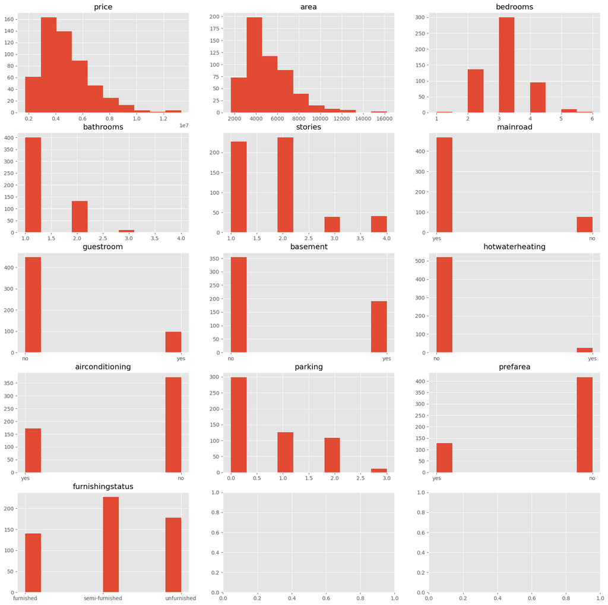

```python
fig, axs=plt.subplots(nrows=5, ncols=3, figsize=(20,20))

axs[0,0].hist(df['price'], bins=10)
axs[0,1].hist(df['area'], bins=10)
axs[0,2].hist(df['bedrooms'], bins=10)
axs[1,0].hist(df['bathrooms'], bins=10)
axs[1,1].hist(df['stories'], bins=10)
axs[1,2].hist(df['mainroad'], bins=10)
axs[2,0].hist(df['guestroom'], bins=10)
axs[2,1].hist(df['basement'], bins=10)
axs[2,2].hist(df['hotwaterheating'], bins=10)
axs[3,0].hist(df['airconditioning'], bins=10)
axs[3,1].hist(df['parking'], bins=10)
axs[3,2].hist(df['prefarea'], bins=10)
axs[4,0].hist(df['furnishingstatus'], bins=10)

axs[0,0].set_title('price')
axs[0,1].set_title('area')
axs[0,2].set_title('bedrooms')
axs[1,0].set_title('bathrooms')
axs[1,1].set_title('stories')
axs[1,2].set_title('mainroad')
axs[2,0].set_title('guestroom')
axs[2,1].set_title('basement')
axs[2,2].set_title('hotwaterheating')
axs[3,0].set_title('airconditioning')
axs[3,1].set_title('parking')
axs[3,2].set_title('prefarea')
axs[4,0].set_title('furnishingstatus')
plt.show()
```

Some meaningful information we can conclude:

The "price" and "area" plots are of relatively similar shape, this could signify that they are correlated. However, more investigation is needed to conclude this.

There is an average of 3 bedrooms which the # of rooms is distributed normally.

Most houses have no basement and there is a considerable amount that do not have any parking, this would suggest condos or some high density housing among the sample. This also tie into the fact that most homes in this dataset have furnished or semi-furnished home.

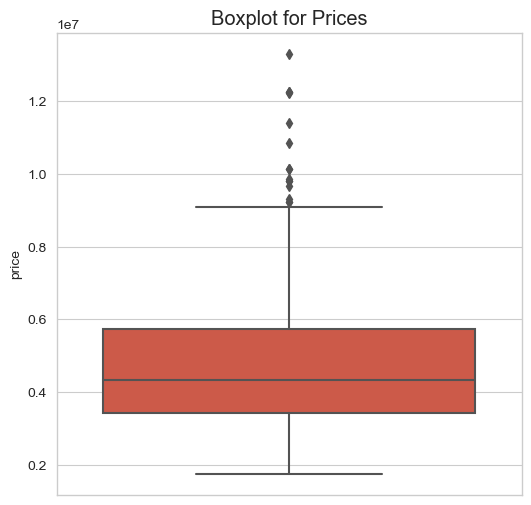

```python
#Distribution of prices

sns.set_style("whitegrid")
plt.figure(figsize=(6, 6))

sns.boxplot(y=df["price"])
plt.title("Boxplot for Prices")

plt.show()
```

```python
# Calculate the median of the 'price' column
median_price = df['price'].median()

print("The median price is:", median_price)
```

```
The median price is: 4340000.0
```

# 3 | Price vs. Attributes

In this section we will analyse the relationship between housing prices and various other attributes.

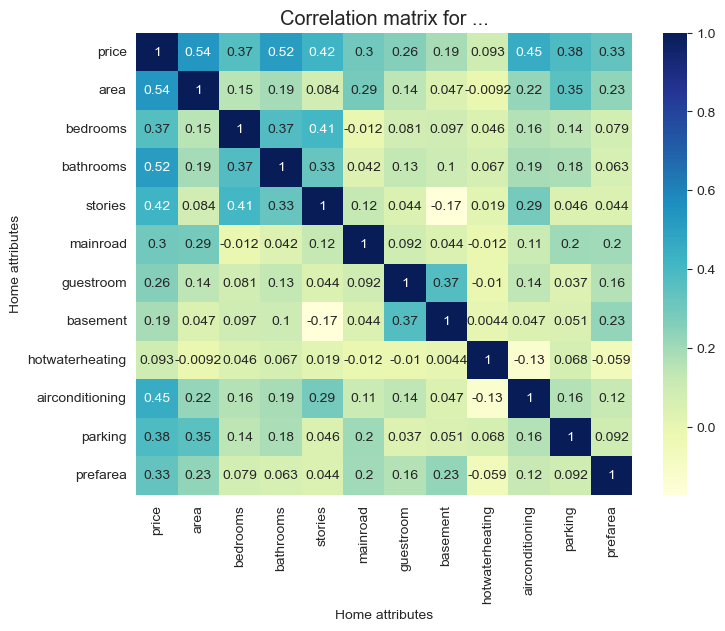

```
price              1.000000
area               0.535997
bathrooms          0.517545
airconditioning    0.452954
stories            0.420712
parking            0.384394
bedrooms           0.366494
prefarea           0.329777
mainroad           0.296898
guestroom          0.255517
basement           0.187057
hotwaterheating    0.093073
Name: price, dtype: float64
```

```python
#Changing yes/no to 1/0
df1 = df.replace(to_replace=['no', 'yes'], value=[0, 1])


##creating correlation matrix for data
correlation_matrix = df1.select_dtypes(include=[np.number]).corr()

plt.figure(figsize=(8,6)) # Set the figure size
sns.heatmap(correlation_matrix, annot = True, cmap='YlGnBu')

#labelling
plt.title("Correlation matrix for ...")
plt.xlabel("Home attributes")
plt.ylabel("Home attributes")

plt.show()



# Sort the correlations in descending order
corr_with_price = correlation_matrix["price"]
sorted_corr = corr_with_price.sort_values(ascending=False)

print(sorted_corr)
```

We can see that the most correlated home attributed are area size, then number of bathrooms, and presence of airconditioning.

Let's take look further into these three attributes.

### 3.1 | Area & price

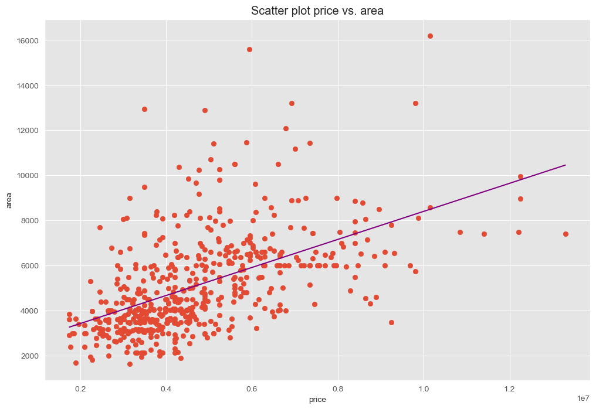

```python
#making scatter plot
plt.scatter(x=df['price'],y=df['area'])

# calculate and plot the fitted line
x = df['price']
y = df['area']
m, b = np.polyfit(x, y, 1)
plt.plot(x, m*x + b, color='purple')


#Checking no mistakes
plt.title("Scatter plot price vs. area")
plt.xlabel("price")
plt.ylabel("area")

#displaying our chart
plt.show()
```

We can see that there is a fair correlation between price and area. However, the majority of our points begin to fall further from our fitted line for the larger price tag homes.

we can plot the standard residuals vs area plot to investigate further our data for "area".

If we see a positive or negative relationship, this would indicate a violation of the assumption of homoscedasticity. This would mean that the variance of the errors is not constant across all values of the predictor variable.

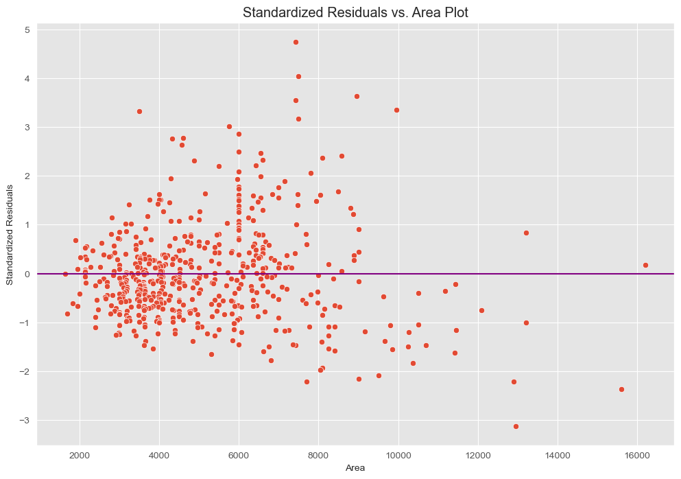

```python
# Fit a linear regression model
X = df['area'] # predictors
y = df['price'] # response variable
model = sm.OLS(y, sm.add_constant(X)).fit()

# Calculate standardized residuals
resid = model.get_influence().resid_studentized_internal

# Add a column of standardized residuals to the DataFrame
df['std_resid'] = resid

# Create a scatter plot of standardized residuals vs. area
sns.scatterplot(x='area', y='std_resid', data=df)

# Add a horizontal line at y=0
plt.axhline(y=0, color='purple')

# Set plot labels and title
plt.xlabel('Area')
plt.ylabel('Standardized Residuals')
plt.title('Standardized Residuals vs. Area Plot')

plt.show()
```

### 3.2 | bathrooms & price

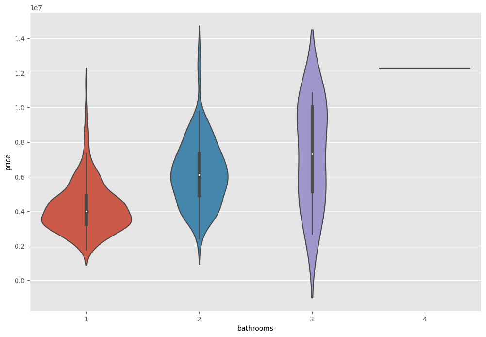

```python
sns.violinplot(x=df['bathrooms'], y=df['price'])
```

We can see that for homes with more bathrooms, the price for the home becomes more expensive on average.

However, there is some variation as we increase the number of bathrooms. This is simply due to less data for higher # of bathrooms.

### 3.3 | airconditioning & price

```
(<Axes: xlabel='airconditioning', ylabel='price'>,)
```

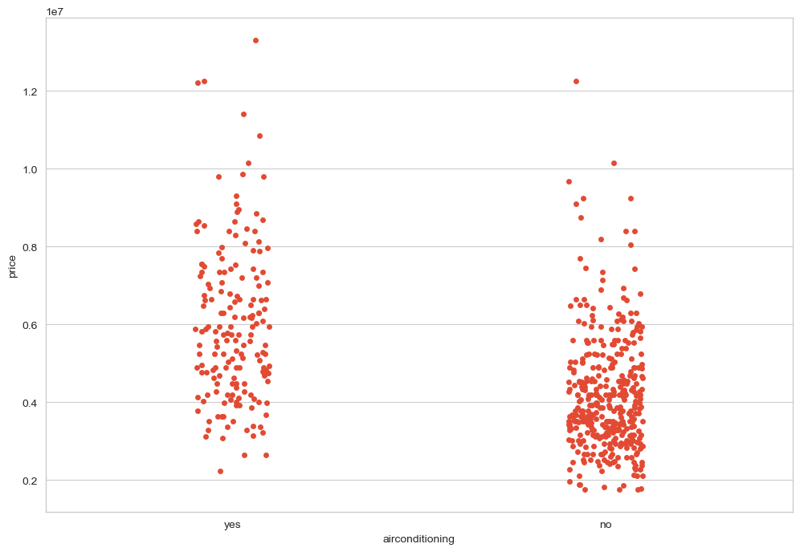

```python
sns.stripplot(x="airconditioning", y="price",  data=df) ,
```

```python
# calculate mean prices for "yes" and "no"
mean_price_yes = df.loc[df['airconditioning'] == 'yes', 'price'].mean()
mean_price_no = df.loc[df['airconditioning'] == 'no', 'price'].mean()

# calculate difference in mean prices
difference_mean_price_ac = mean_price_yes - mean_price_no

# calculate standard deviations for "yes" and "no"
std_price_yes = df.loc[df['airconditioning'] == 'yes', 'price'].std()
std_price_no = df.loc[df['airconditioning'] == 'no', 'price'].std()


print("mean price for ac \u03BC\u2081 =", mean_price_yes.round(3))
print("mean price for no ac \u03BC\u2082 =", mean_price_no.round(3))
print("mean price for \u03BC\u2081-\u03BC\u2082 =", difference_mean_price_ac.round(3))
print("standard deviation for ac \u03C3\u2081 =", std_price_yes)
print("standard deviation for ac \u03C3\u2082 =", std_price_no)
```

```
mean price for ac μ₁ = 6013220.581
mean price for no ac μ₂ = 4191939.678
mean price for μ₁-μ₂ = 1821280.903
standard deviation for ac σ₁ = 1998149.474992723
standard deviation for ac σ₂ = 1493711.7609608257
```

It is clear that homes in this dataset with no ac as usually cheaper.

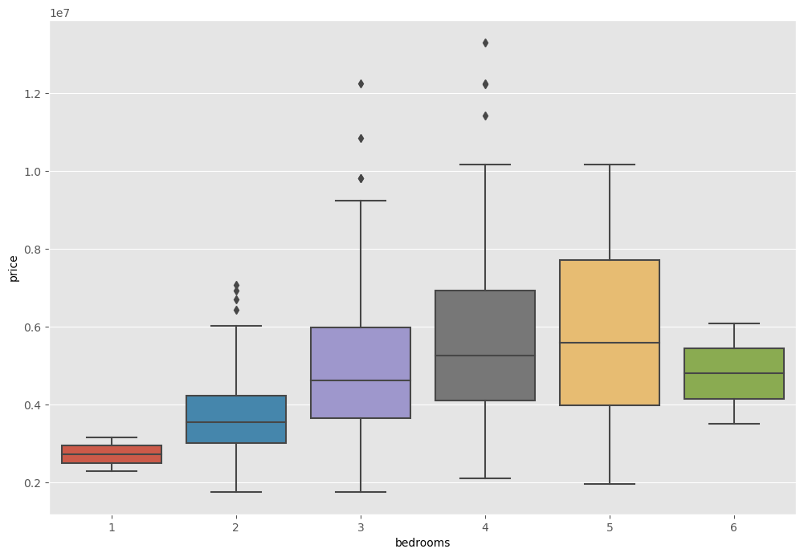

```python
sns.boxplot(x=df['bedrooms'], y=df['price'])
plt.show()
```

Also checking # of bedroooms, we can conclude relatively the same conclusion as bathrooms. There is an upward trend in the price for more bathroooms in the household.

While this can be said, it should be noted that there is more variation in the price for houses for larger # of bathrooms.

# 4 | Conclusion

We can also use python's feature importance, which helps to calculate which features (attributes) are the most important for predicting the target (price) variable.

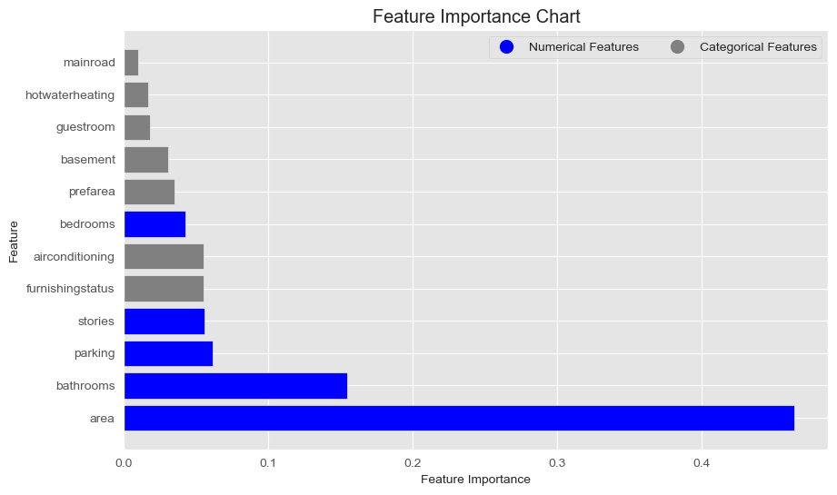

```python
# Load data from csv
data = pd.read_csv('/Users/evanvolpini/Desktop/personal/Portfolio/Housing.csv')

# Convert categorical variables to numerical
categorical_cols = ['mainroad', 'guestroom', 'basement', 'hotwaterheating', 'airconditioning', 'prefarea', 'furnishingstatus']
for col in categorical_cols:
    encoder = LabelEncoder()
    data[col] = encoder.fit_transform(data[col])

# Split the data into features and target
X = data.drop('price', axis=1)
y = data['price']

# Fit a random forest regressor
clf = RandomForestRegressor(n_estimators=100, random_state=42)
clf.fit(X, y)

# Get feature importances and order them in descending order
importances = clf.feature_importances_
indices = importances.argsort()[::-1]
features = X.columns[indices]

# Set the color for each feature and create a legend
colors = ['gray' if col in categorical_cols else 'blue' for col in features]
legend = {'Numerical Features': 'blue', 'Categorical Features': 'gray'}

# Plot feature importances
plt.figure(figsize=(10, 6))
plt.barh(range(len(importances)), importances[indices], align='center', color=colors)
plt.yticks(range(len(importances)), features)
plt.xlabel('Feature Importance')
plt.ylabel('Feature')
plt.title('Feature Importance Chart')

# Add legend
patches = [plt.plot([], [], marker='o', ms=10, ls="", mec=None, color=color, label=label)[0]
           for label, color in legend.items()]
plt.legend(handles=patches, ncol=2, loc='upper right')

plt.show()
```

Based on our investigation of the features that lead to high housing costs in this dataset, we conclude that the "area" of the house is the most important factor, followed by the number of "bathrooms". The subsequent features are similar in importance.

As our Feature Importance plot indicates relatively the same conclusion as our correlation matrix, we can say that our analysis is correct.

This suggests that when buying a home, one should prioritize properties based on area, and # of bathrooms. These features have a strong influence on the overall price of the property and are therefore important factors to consider. Then, one can consider features such as parking and ariconditioning.

However, it's also important to consider other factors that may affect the suitability of a property for one's individual needs, such as the number of bedrooms, the presence of additional amenities like a guest room or basement, and the location of the property. A thorough assessment of all relevant factors can help ensure that one makes an informed decision when buying a home.